# 산점도 : 두가지 연속 변수의 관계를 보여주기 위해서 사용 geom_point() 는 점을 그리기 위한 것

##5.1 산점도 그리기

## 산점도 : 두가지 연속 변수의 관계를 보여주기 위해서 사용 geom_point() 는 점을 그리기 위한 것

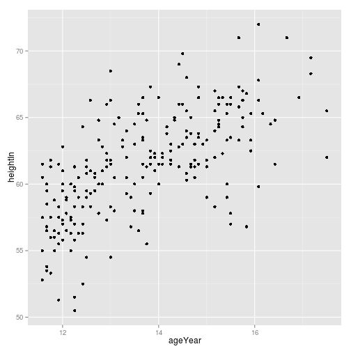

```r
library(ggplot2)
library(gcookbook)
ggplot(heightweight, aes(x=ageYear, y=heightIn)) + geom_point()
```

## size, shape 조절 geom_point(size or shape)

## shape defualt 16, size default = 2

##5.2 변수 기준으로 데이터 묶기

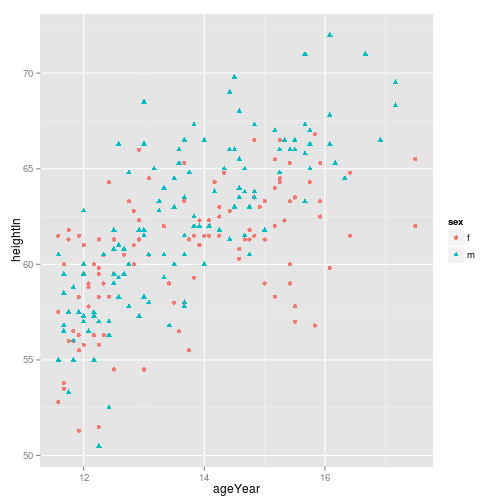

```r
ggplot(heightweight, aes(x=ageYear, y=heightIn, colour=sex, shape=sex)) + geom_point()  ## scale_shape_manual(values=c(1,2)) + sclae_color_brewer(palette="Set1") p.75
```

##5.4 연속변수를 색상이나 크기에 대입(세번째 연속변수 나타내고 싶을 때)

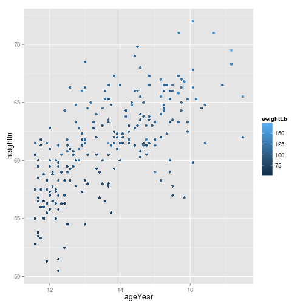

```r
ggplot(heightweight, aes(x=ageYear, y=heightIn, color=weightLb)) + geom_point()
```

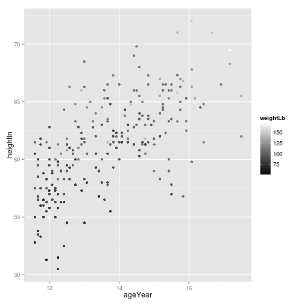

```r
ggplot(heightweight, aes(x=ageYear, y=heightIn, color=weightLb)) + geom_point() + scale_color_gradient(low="black", high="white")
```

##5.5 겹치는 점 다루기, 데이터 점이 너무 많아서 겹칠때

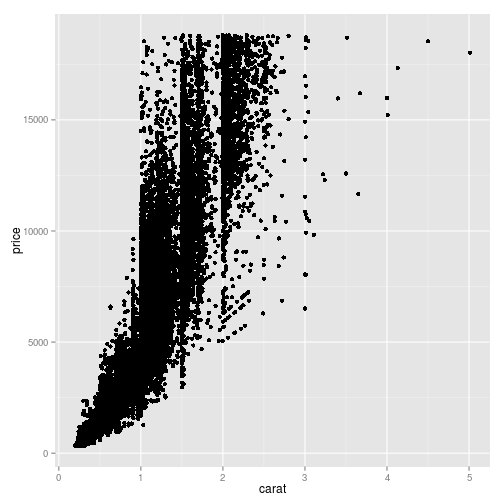

```r
sp <- ggplot(diamonds, aes(x=carat, y=price))
sp + geom_point()
```

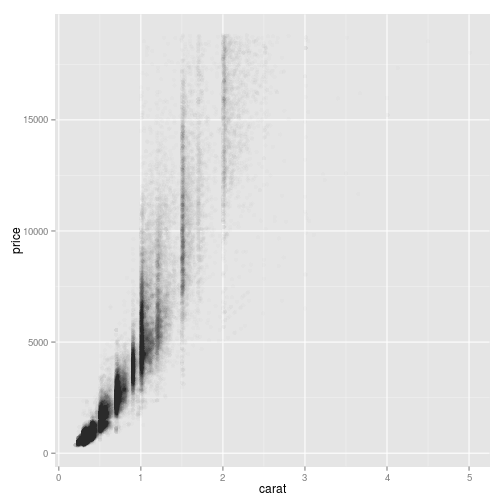

```r
sp + geom_point(alpha=.01)  ##alpha 투명도 설정
```

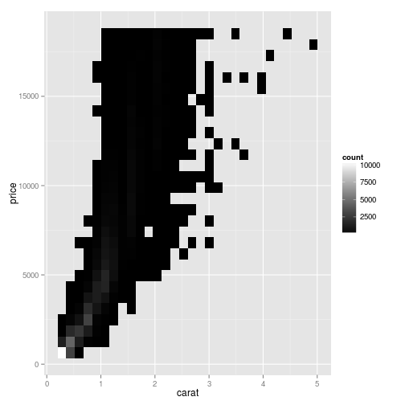

```r
sp + stat_bin2d(binds=50) + scale_fill_gradient(low="black", high="white")  ##binning(네모난 상자로데이터 묶어서)
```

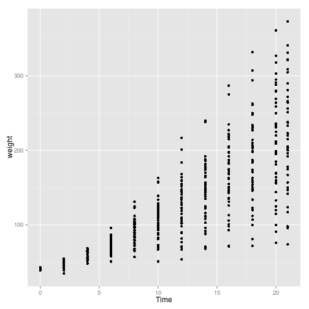

```r
sp1 <- ggplot(ChickWeight, aes(x=Time, y=weight))
sp1 + geom_point()
```

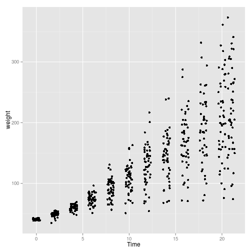

```r
sp1 + geom_point(position="jitter")     ##jitter(조금씩 움직여) 표시가능
```

##5.6 회귀선 추가

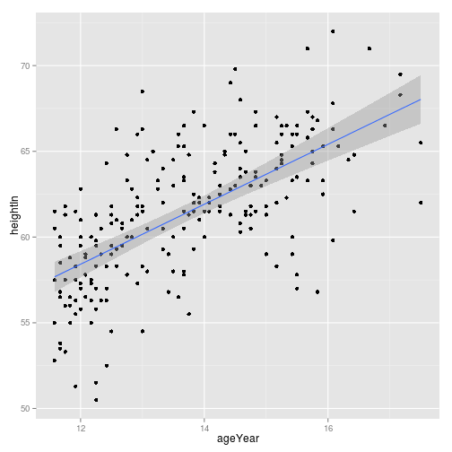

```r
sp <-ggplot(heightweight, aes(x=ageYear, y=heightIn))
sp + geom_point() + stat_smooth(method=lm, level=0.99)    ##lm 선형모형 ##se=FALSE로 신뢰구간 끌 수도 있음
```

## error..

[output not shown]

[figure not shown]

#5.7 이미 만들어진 모형의 적합선 추가

```r
model <- lm(heightIn ~ ageYear + I(ageYear^2), data = heightweight) #ageYear 를 heightIn의 예측변수로 두고
model
```

```
##
## Call:
## lm(formula = heightIn ~ ageYear + I(ageYear^2), data = heightweight)
##
## Coefficients:
##  (Intercept)       ageYear  I(ageYear^2)
##      -10.314         8.667        -0.248
```

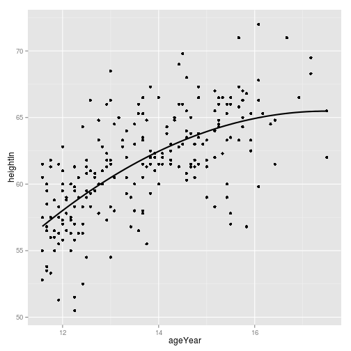

```r
xmin <- min(heightweight$ageYear) #내삽법(주어진 데이터 사이의 미지의 값 구하기) ageYear 기준
xmax <- max(heightweight$ageYear)

predicted <- data.frame(ageYear=seq(xmin, xmax, length.out=100))   ##length는 빈도수, seq는 벡터 생성

predicted$heightIn <- predict(model,predicted)  #heightIn의 예측값 계산
sp <- ggplot(heightweight, aes(x=ageYear, y=heightIn)) + geom_point()
sp + geom_line(data=predicted, size =1)
```

model <- lm(heightIn ~ ageYear, heightweight) summary(model)

#5.10 산점도에 여백 러그 추가

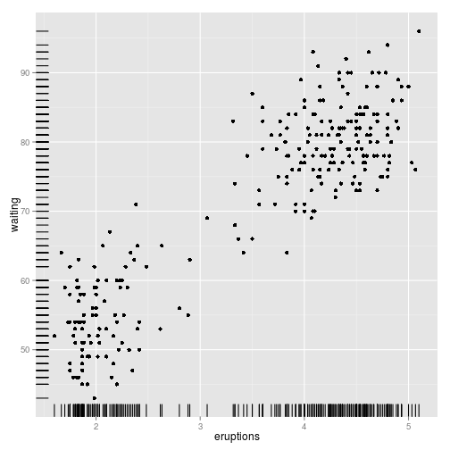

```r
ggplot(faithful, aes(x=eruptions, y=waiting)) + geom_point() + geom_rug()  #한눈에 알아볼 수 있게
```

#5.11 산점도 점에 라벨 붙이기, annotate() or geom_text()

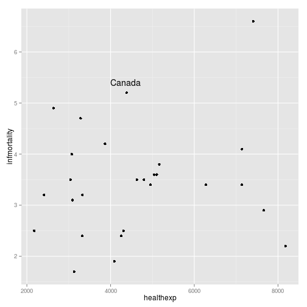

```r
sp <- ggplot(subset(countries, Year==2009 & healthexp>2000), aes(x=healthexp, y=infmortality)) + geom_point() #의료비와 1000명 대비 유아 사망률 관계, 2009년
sp + annotate("text", x=4350, y=5.4, label="Canada")
```

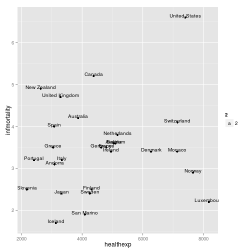

```r
sp + geom_text(aes(label=Name, size=2, vjust=0))
```

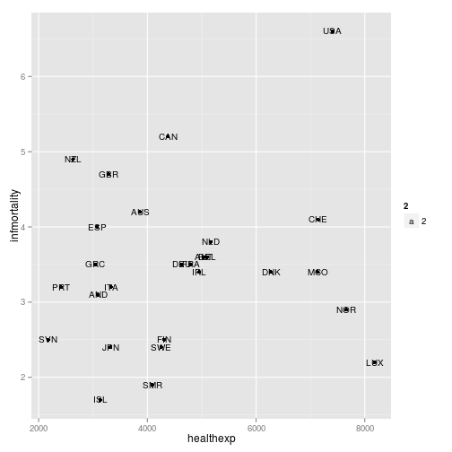

```r
sp + geom_text(aes(label=Code, size=2))
```

```r
## vjust로 텍스트 상하조절, hjust 좌우
```

##5.12 거품 그래프(점의 영역이 수치형 값에 비례하는 그래프)

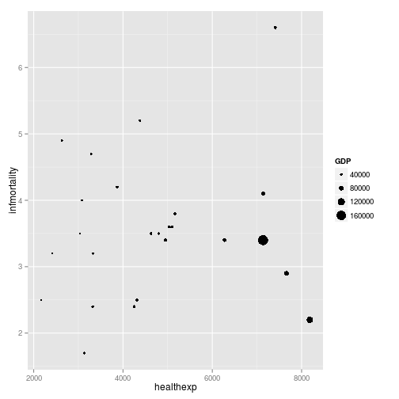

```r
cdat <- subset(countries, Year==2009 & healthexp>2000)
p <- ggplot(cdat, aes(x=healthexp, y=infmortality, size=GDP)) + geom_point()
p    #GDP를 반지름에 대입
```

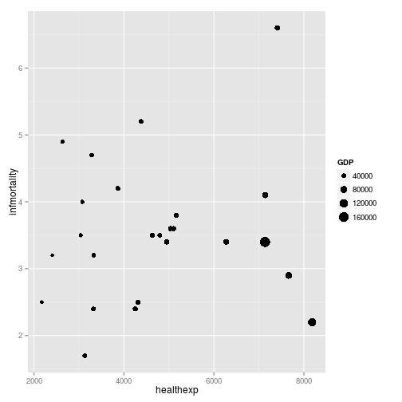

```r
p + scale_size_area()   #GDP를 영역에 대입, 원의 크기 확대
```

```r
#c2009 <- subset(countries, Year==2009, select=c(Name, GDP, laborrate, healthexp, infmortality))   ##error

#pairs(c2009[,2:5])   2~5열까지 사용
```